# Creating Plots with ggplot

Alongside the plotting functions we learnt about in script 2, there is a language to create prettier and more elegant data visualisations than base R: `ggplot2`, the *grammar of graphics*. You can learn all about it on [this website](https://r4ds.had.co.nz/data-visualisation.html), [this free online course](https://www.oreilly.com/videos/data-visualization-in/9781491963661/) or [this Youtube webinar](https://www.youtube.com/watch?v=h29g21z0a68).

To use `ggplot2`, you are going to need to install the `tidyverse` collection of packages, which includes, alongside `ggplot2`, a host of other packages with functions that are widely used to wrangle with, model and visualise data in **R**. All these functions simply spice up things you can still do in base **R** - but usually with longer lines of code. To keep it simple and avoid confusion we are not going to cover it much in this course. However, if you feel like you’ve grasped the basics of data visualisation, you may want to try your hand to reproduce the graphs from script 2 with `ggplot2` instead of base *R*. The code to do so is below and gives you a sense for the syntax of `ggplot`.

```r
#install.packages("tidyverse") # installs the package you need
library(tidyverse) #loads the package
```

```r
#load the data
qog <- read.csv("qog.csv")
```

## Barplots

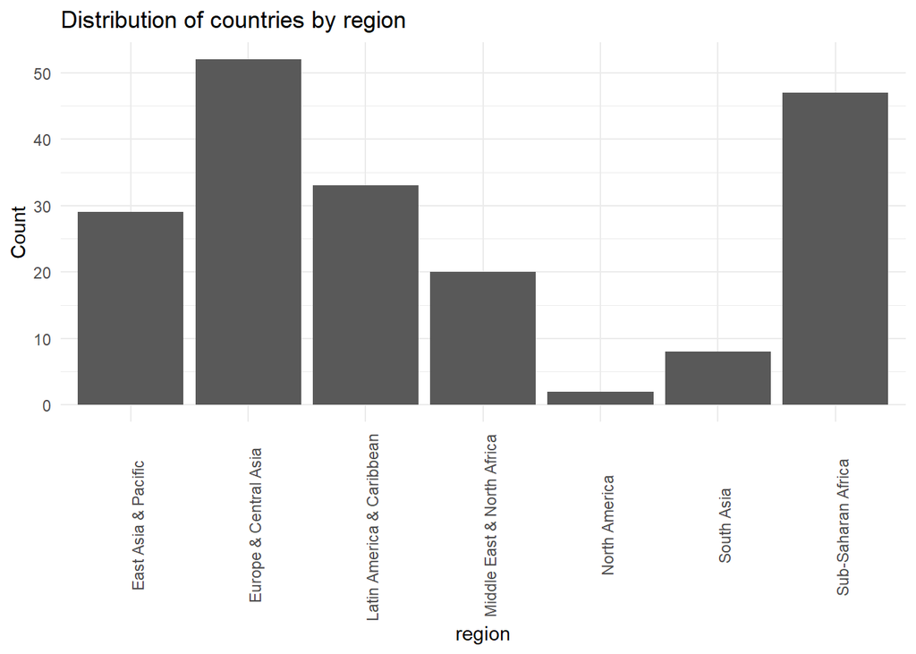

```r
qog2 <- data.frame(table(region = qog$region)) #creates a dataframe of frequencies

ggplot(data = qog2, mapping = aes(x = region, y = Freq)) +
  geom_bar(stat = "identity") + #makes the barplot
  theme_minimal() + #removes ugly grey background
  theme(axis.text.x = element_text(angle = 90, vjust = 1)) + #rotates the x axis text
  ylab("Count") + #creates the y axis label
  ggtitle("Distribution of countries by region") #creates the title
```

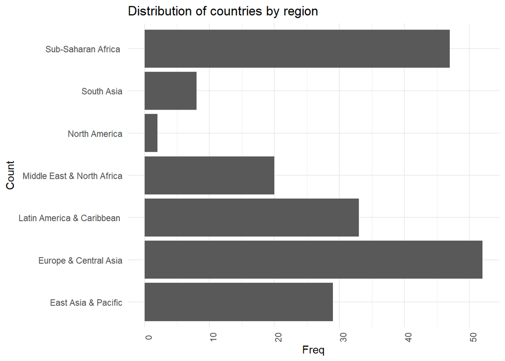

```r
ggplot(data = qog2, mapping = aes(x = region, y = Freq)) +
  geom_bar(stat = "identity") +
  theme_minimal() +
  theme(axis.text.x = element_text(angle = 90, vjust = 1)) +
  xlab("Count") +
  ggtitle("Distribution of countries by region") +
  coord_flip() #flips x and y axes
```

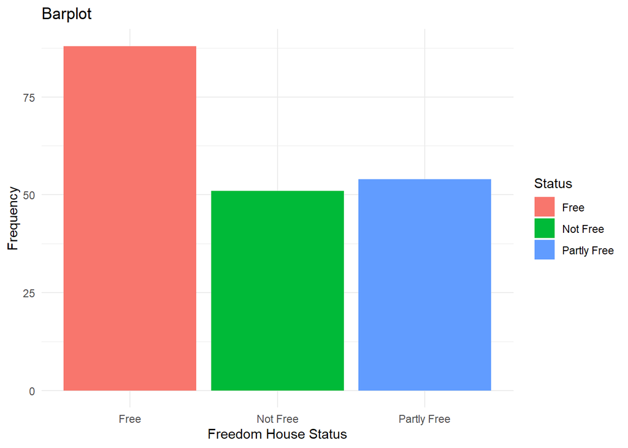

```r
qog3 <- data.frame(table(Status = qog$freedomhouse_status)) #creates a dataframe of frequencies

ggplot(data = qog3, mapping = aes(x = Status, y = Freq, fill = Status)) +
geom_bar(stat = "identity") +
theme_minimal() + ylab("Frequency") + xlab("Freedom House Status") +
ggtitle("Barplot")
```

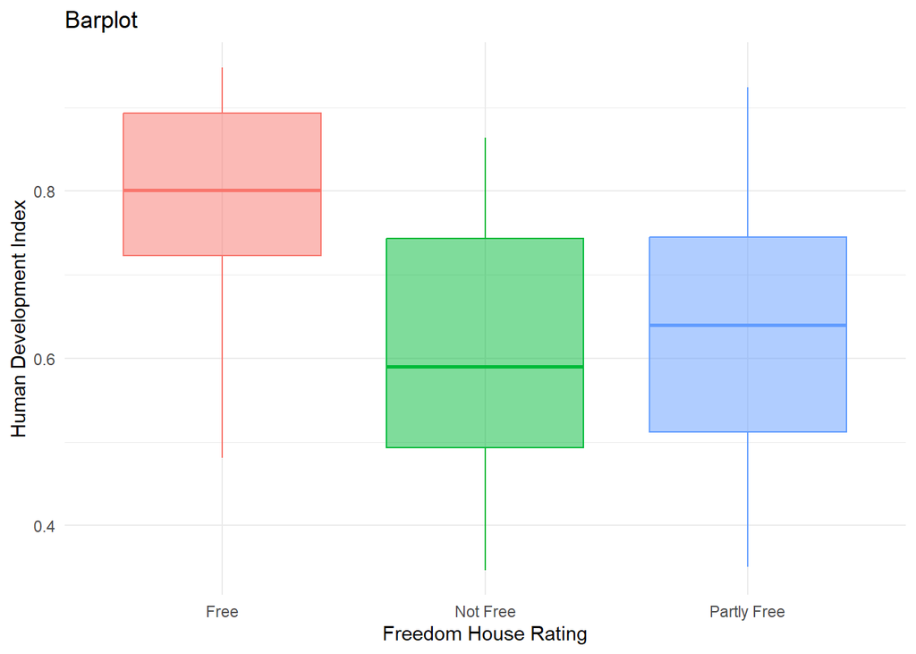

```r
ggplot(data = qog, mapping = aes(x = freedomhouse_status,
                                 y = human_devt_index,
                                 col = freedomhouse_status,
                                 fill = freedomhouse_status)) +
  geom_boxplot(alpha = 0.5) + theme_minimal() +
  xlab("Freedom House Rating") + ylab("Human Development Index") +
  theme(legend.position = "none") + ggtitle("Barplot")
```

## Histogram

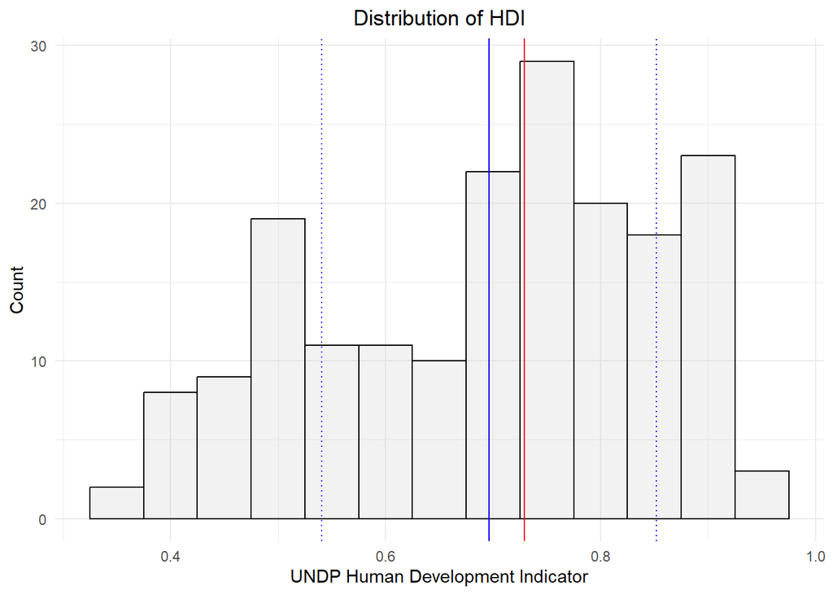

```r
ggplot(data = qog, mapping = aes(x = human_devt_index)) +
  geom_histogram(binwidth = 0.05, fill = "grey",
                 col = "black", alpha = 0.2) +
#alpha (0 to 1) makes the fill more or less transparent
  theme_minimal() +
  xlab("UNDP Human Development Indicator") + ylab("Count") +
  ggtitle("Distribution of HDI") +
  theme(plot.title = element_text(hjust = 0.5)) +
#centers the plot title
  geom_vline(xintercept = median(qog$human_devt_index, na.rm=TRUE), col = "red") +
  geom_vline(xintercept = mean(qog$human_devt_index, na.rm=TRUE), col = "blue") +
  geom_vline(xintercept = mean(qog$human_devt_index, na.rm=TRUE) +
  sd(qog$human_devt_index, na.rm=TRUE), col = "blue", lty = 3) +
  geom_vline(xintercept = mean(qog$human_devt_index, na.rm=TRUE) -
  sd(qog$human_devt_index, na.rm=TRUE), col = "blue", lty = 3)
```

### Single Histogram with Various Groups

You can plot a histogram by groups using the `color/fill` argument.

Note that the bars will be stacked - you can use the `position="identity"` or ``position="dodge"` arguments in the `geom_histogram()` command to avoid this but these other approaches are not ideal if you have more than two groups - as bars by group will be plotted next to each other.

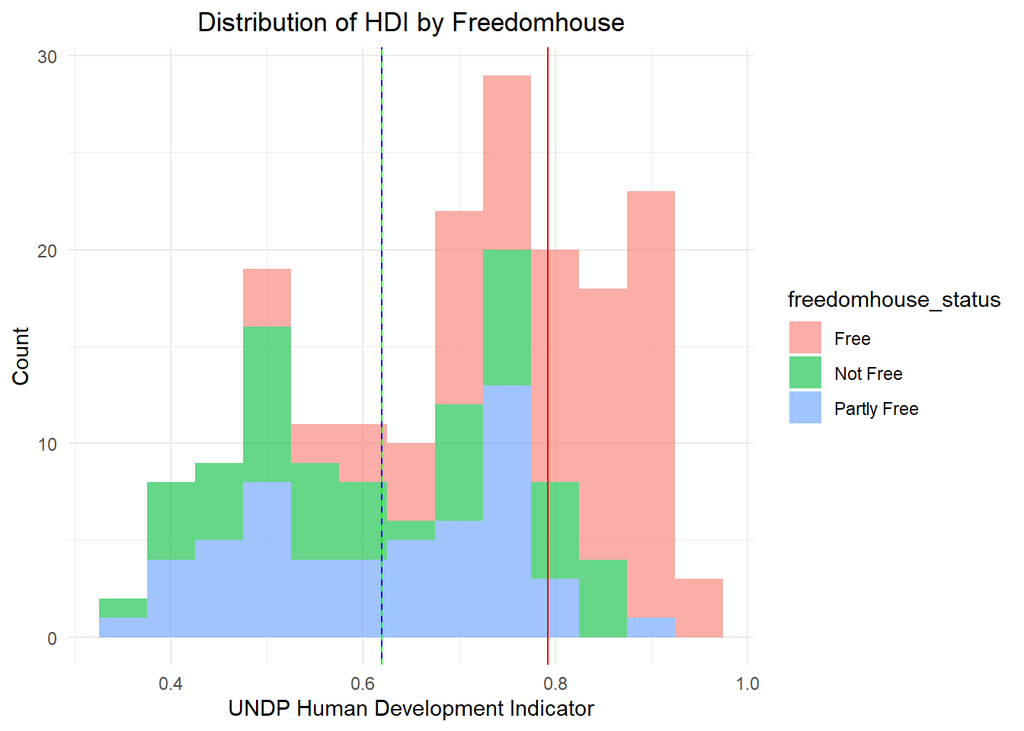

```r
ggplot(data = qog, mapping = aes(x = human_devt_index, fill= freedomhouse_status)) +
  geom_histogram(binwidth = 0.05, alpha = 0.6) +
  theme_minimal() +
  xlab("UNDP Human Development Indicator") + ylab("Count") +
  ggtitle("Distribution of HDI by Freedomhouse") +
  theme(plot.title = element_text(hjust = 0.5)) +
#centers the plot title
  geom_vline(xintercept = mean(qog$human_devt_index[qog$freedomhouse_status=="Free"], na.rm=TRUE), col = "red") +
  geom_vline(xintercept = mean(qog$human_devt_index[qog$freedomhouse_status=="Partly Free"], na.rm=TRUE), col = "blue") +
  geom_vline(xintercept = mean(qog$human_devt_index[qog$freedomhouse_status=="Not Free"], na.rm=TRUE), col="green", lty=2)
```

### Density Plot

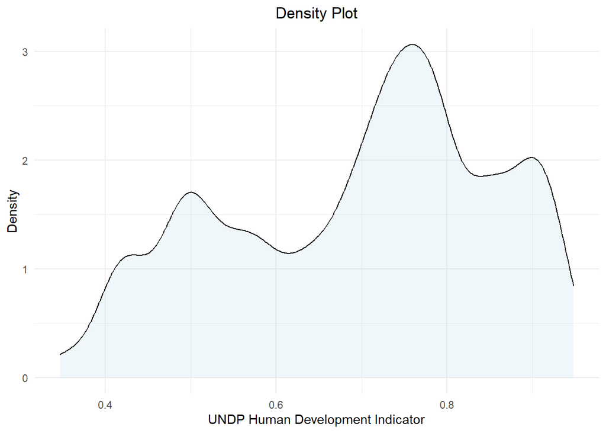

```r
ggplot(data = qog, mapping = aes(x = human_devt_index)) +
  geom_density(bw = 0.025, fill = "lightblue", alpha = 0.2) +
  #bw sets the bandwidth of the density plot
  theme_minimal() +
  xlab("UNDP Human Development Indicator") + ylab("Density") +
  ggtitle("Distribution of HDI") +
  theme(plot.title = element_text(hjust = 0.5)) + ggtitle("Density Plot")
```

## Scatterplots

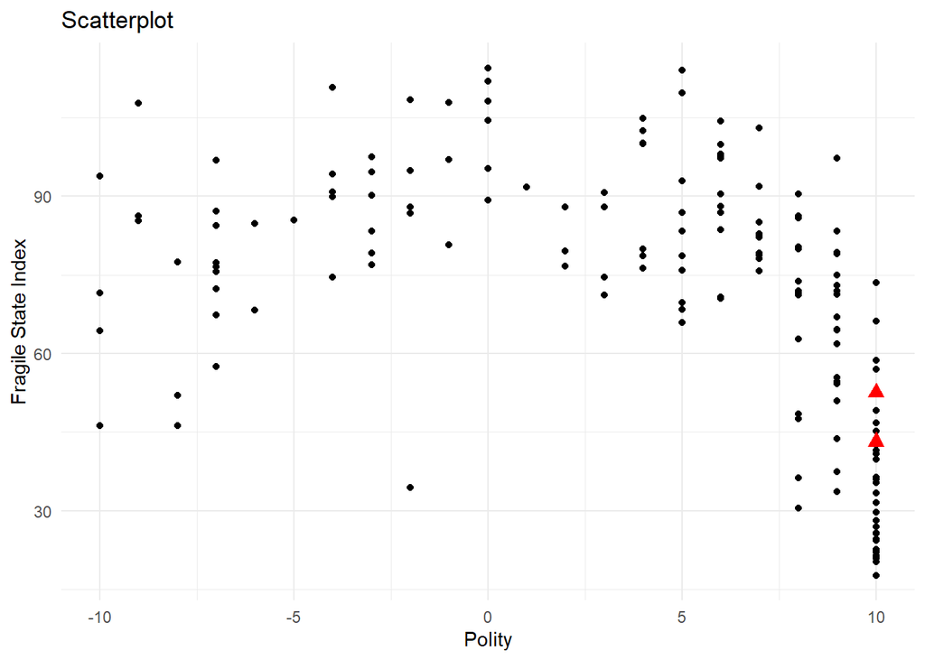

```r
ggplot(data = qog, mapping = aes(x = polity,
                                 y = fragile_state_index)) +
  geom_point() + theme_minimal() +
  scale_color_manual(values = c("black", "red")) +
  geom_point(data = subset(qog, country %in% c("Italy", "Greece")), col = "red",
  shape = 17, size = 3) +
  ylab("Fragile State Index") + xlab("Polity") + ggtitle("Scatterplot")
```

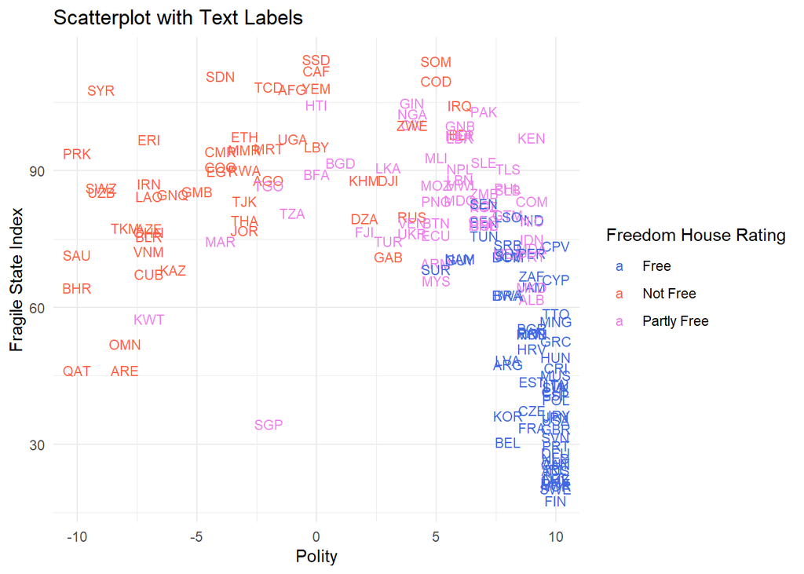

```r
ggplot(data = qog, mapping = aes(x = polity,
  y = fragile_state_index, label = iso3c, col = freedomhouse_status)) +
  geom_text(size = 3) + theme_minimal() +
  scale_color_manual(values = c("royalblue", "tomato", "violet"),
                     labels = c("Free", "Not Free", "Partly Free"),
                     name = "Freedom House Rating") +
  ylab("Fragile State Index") +
  xlab("Polity") + ggtitle("Scatterplot with Text Labels")
```